# TPG Praktikum

Rahmandani G1401231029

2025-11-11

```r
library(tidyverse)
library(GGally)
library(factoextra)
```

```r
library(corrplot)
library(cowplot)
library(scales)
library(cluster)
library(ggplot2)
```

# link =- https://www.kaggle.com/datasets/vetrirah/customer

# Import

```r
path_file <- "C:/Users/PC/Downloads/Test.csv"

df_full <- read.csv(path_file, stringsAsFactors = FALSE)

# Hapus baris yang memiliki NA di seluruh kolom yang akan dipakai
df <- na.omit(df_full)
```

# Pilih kolom yang diperlukan & pastikan numerik

```r
kolom_pakai <- c("Age", "Work_Experience", "Family_Size", "Spending_Score")

# Pastikan kolom ada
missing_kolom <- setdiff(kolom_pakai, names(df))
if (length(missing_kolom) > 0) stop("Kolom yang hilang: ", paste(missing_kolom, collapse = ", "))

df <- df %>% select(all_of(kolom_pakai))

# Jika Spending_Score berbentuk kategori (Low/Average/High), konversi ke numeric 1-3
if (is.character(df$Spending_Score) || is.factor(df$Spending_Score)) {
  df$Spending_Score <- as.numeric(factor(df$Spending_Score,
                                         levels = c("Low", "Average", "High"),
                                         labels = c(1, 2, 3)))
}


for (col in names(df)) {
  if (!is.numeric(df[[col]])) {
    warning("Kolom '", col, "' bukan numeric. Mencoba konversi otomatis.")
    df[[col]] <- as.numeric(df[[col]])
  }
}


if (any(is.na(df))) {
  stop("Terdapat NA setelah konversi ke numeric. Periksa nilai non-numeric di kolom: ",
       paste(names(df)[colSums(is.na(df)) > 0], collapse = ", "))
}

str(df)
```

```
## 'data.frame':    2267 obs. of  4 variables:
##  $ Age            : int  36 37 69 59 47 61 47 50 19 22 ...
##  $ Work_Experience: num  0 8 0 11 0 5 1 2 0 0 ...
##  $ Family_Size    : num  1 4 1 2 5 3 3 4 4 3 ...
##  $ Spending_Score : num  1 2 1 3 3 1 2 2 1 1 ...
##  - attr(*, "na.action")= 'omit' Named int [1:360] 5 21 22 24 27 30 41 51 52 77 ...
##   ..- attr(*, "names")= chr [1:360] "5" "21" "22" "24" ...
```

```r
summary(df)
```

```
##       Age        Work_Experience   Family_Size    Spending_Score
##  Min.   :18.00   Min.   : 0.000   Min.   :1.000   Min.   :1.000
##  1st Qu.:30.00   1st Qu.: 0.000   1st Qu.:2.000   1st Qu.:1.000
##  Median :41.00   Median : 1.000   Median :2.000   Median :1.000
##  Mean   :43.46   Mean   : 2.548   Mean   :2.836   Mean   :1.529
##  3rd Qu.:52.00   3rd Qu.: 4.000   3rd Qu.:4.000   3rd Qu.:2.000
##  Max.   :89.00   Max.   :14.000   Max.   :9.000   Max.   :3.000
```

```r
sum(is.na(df))
```

```
## [1] 0
```

# Eksplorasi

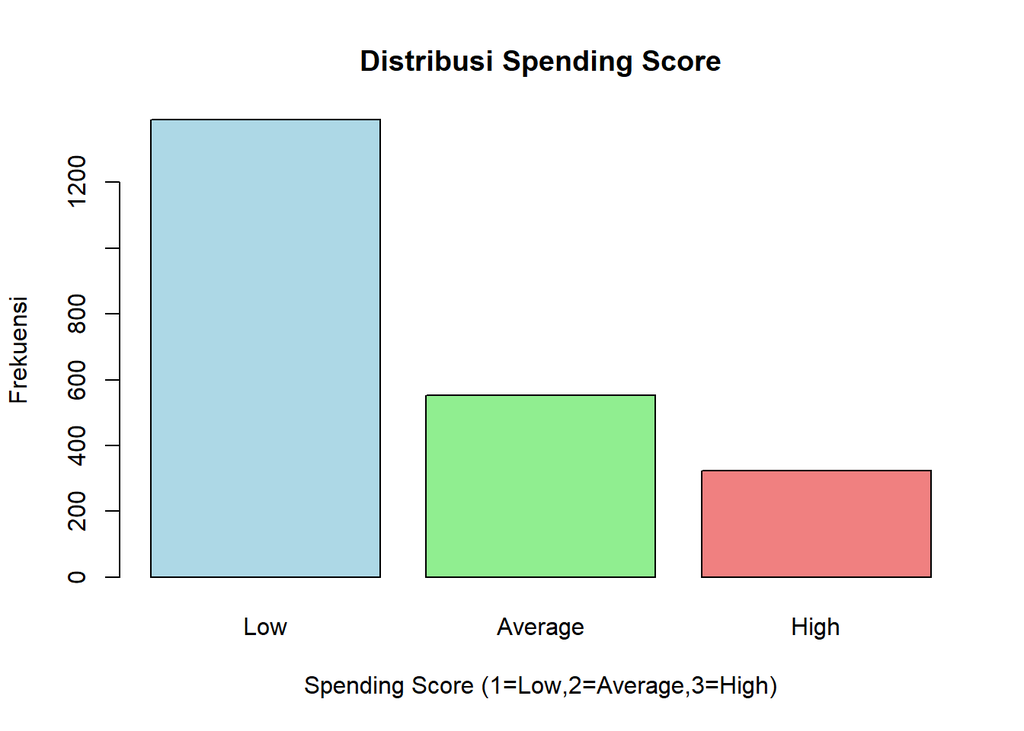

```r
# Distribusi Spending Score (sebagai kategori 1-3)
barplot(table(df$Spending_Score),
        main = "Distribusi Spending Score",
        xlab = "Spending Score (1=Low,2=Average,3=High)",
        ylab = "Frekuensi",
        col = c("lightblue", "lightgreen", "lightcoral"),
        names.arg = c("Low", "Average", "High"))
```

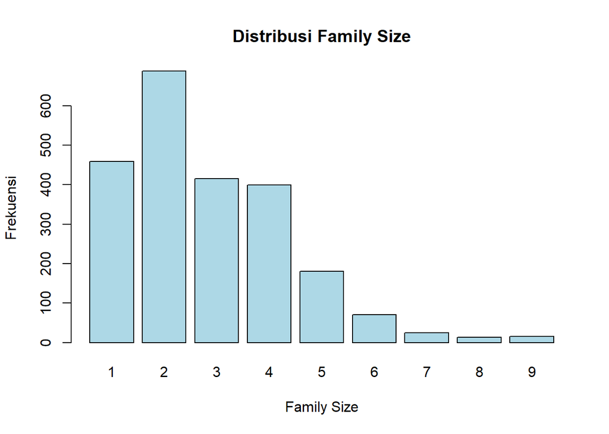

```r
barplot(table(df$Family_Size),
        main = "Distribusi Family Size",
        xlab = "Family Size",
        ylab = "Frekuensi",
        col = "lightblue")
```

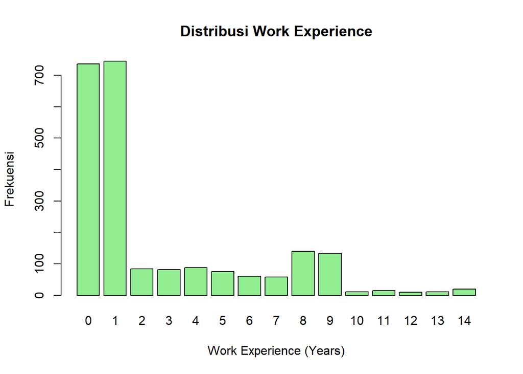

```r
barplot(table(df$Work_Experience),
        main = "Distribusi Work Experience",
        xlab = "Work Experience (Years)",
        ylab = "Frekuensi",
        col = "lightgreen")
```

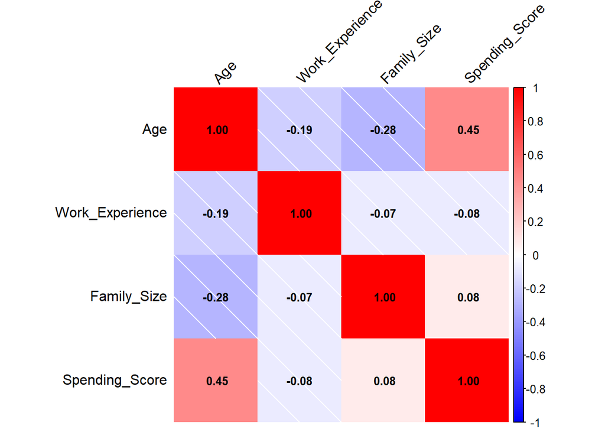

```r
# Korelasi Pearson antar variabel numerik
cor_mat <- cor(df, use = "complete.obs", method = "pearson")
corrplot(cor_mat,
         method = "shade",
         addCoef.col = "black",
         tl.col = "black",
         tl.srt = 45,
         number.cex = 0.8,
         col = colorRampPalette(c("blue", "white", "red"))(200))
```

# PCA

```r
pca_res <- prcomp(df, center = TRUE, scale. = TRUE)

# Ringkasan PCA
summary(pca_res)
```

```
## Importance of components:
##                           PC1    PC2    PC3    PC4
## Standard deviation     1.2444 1.0573 0.9618 0.6393
## Proportion of Variance 0.3871 0.2795 0.2313 0.1022
## Cumulative Proportion  0.3871 0.6666 0.8978 1.0000
```

```r
# Varians & proporsi varians
var_explained <- pca_res$sdev^2
prop_var <- var_explained / sum(var_explained)
prop_var
```

```
## [1] 0.3871046 0.2794756 0.2312571 0.1021626
```

# Scree plot & biplot

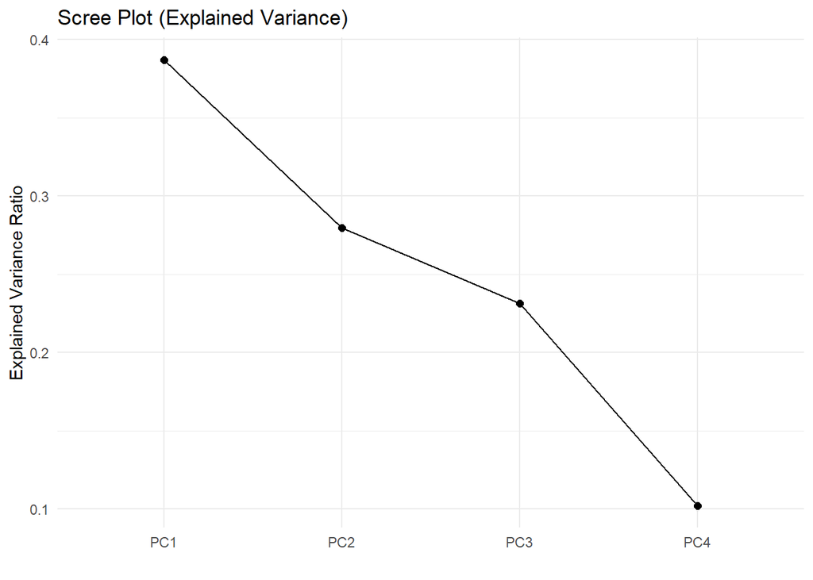

```r
df_scree <- data.frame(PC = factor(paste0("PC", 1:length(prop_var)),
                                   levels = paste0("PC", 1:length(prop_var))),
                       prop_var = prop_var)

ggplot(df_scree, aes(x = PC, y = prop_var, group = 1)) +
  geom_line() + geom_point(size = 2) +
  labs(title = "Scree Plot (Explained Variance)", y = "Explained Variance Ratio", x = "") +
  theme_minimal()
```

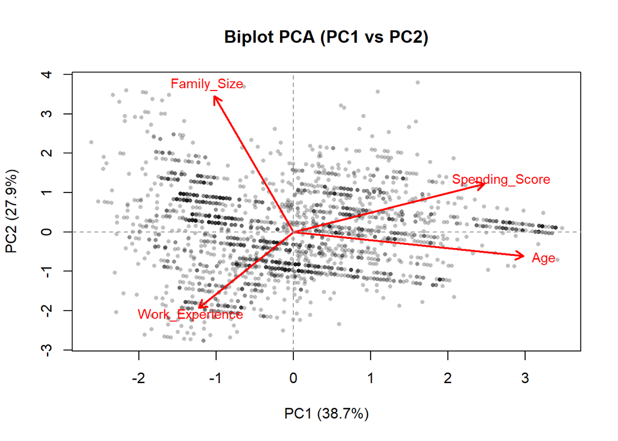

```r
# Biplot sederhana (PC1 vs PC2) menggunakan base plot (lebih kontrol)
pcs <- pca_res$x[, 1:2]
loadings <- pca_res$rotation[, 1:2]

plot(pcs[,1], pcs[,2],
     pch = 16, cex = 0.6, col = rgb(0,0,0,0.25),
     xlab = paste0("PC1 (", round(prop_var[1]*100,1), "%)"),
     ylab = paste0("PC2 (", round(prop_var[2]*100,1), "%)"),
     main = "Biplot PCA (PC1 vs PC2)")

# panah loadings
arrows(0,0, loadings[,1]*max(abs(pcs))*1.1, loadings[,2]*max(abs(pcs))*1.1,
       length = 0.1, col = "red", lwd = 2)
text(loadings[,1]*max(abs(pcs))*1.2, loadings[,2]*max(abs(pcs))*1.2,
     labels = rownames(loadings), col = "red", cex = 0.9)
abline(h=0, v=0, lty=2, col="grey60")
```

# persiapan Clustering

```r
n_pc <- 2
skor_pca <- as.data.frame(pca_res$x)
data_pca <- skor_pca[, 1:n_pc, drop = FALSE]
colnames(data_pca) <- paste0("PC", 1:n_pc)
head(data_pca)
```

```
##           PC1        PC2
## 1 -0.23014481 -0.7639840
## 2 -0.55746147  0.1054656
## 3  1.16899136 -1.0530744
## 4  1.23250231 -1.1602888
## 6  1.22021364  2.0513800
## 7  0.07490112 -0.6173119
```

# (WSS) untuk memilih k

```r
set.seed(42)
max_k <- 10
wss <- sapply(1:max_k, function(k) kmeans(data_pca, centers = k, nstart = 25)$tot.withinss)
df_wss <- data.frame(k = 1:max_k, wss = wss)

# Heuristik sederhana: second derivative (bisa tidak sempurna)
diff1 <- diff(wss)
diff2 <- diff(diff1)
if (length(diff2) >= 1) {
  elbow_otomatis <- which.max(-diff2) + 1
} else {
  elbow_otomatis <- 2
}
message("Estimasi elbow otomatis: k = ", elbow_otomatis)
```

```
## Estimasi elbow otomatis: k = 9
```

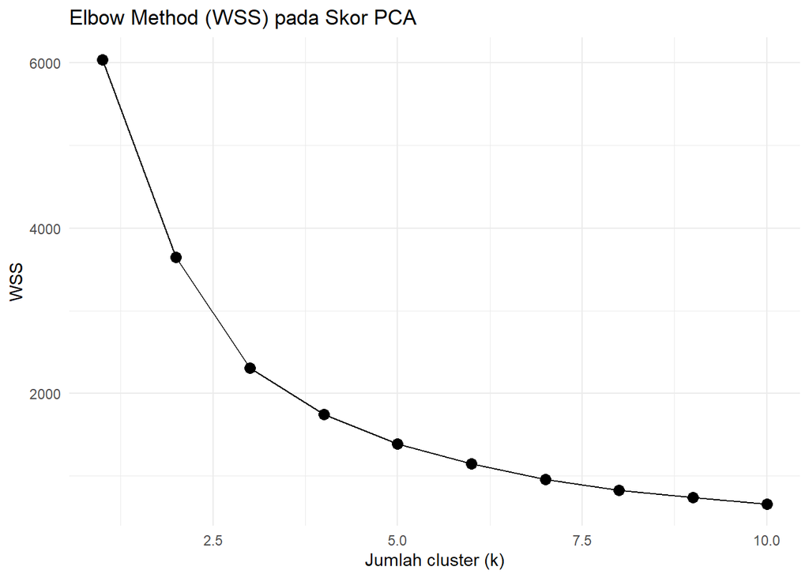

```r
ggplot(df_wss, aes(x = k, y = wss)) +
  geom_point(size = 3) + geom_line() +
  labs(title = "Elbow Method (WSS) pada Skor PCA", x = "Jumlah cluster (k)", y = "WSS") +
  theme_minimal()
```

# Silhoutte

```r
min_k <- 2; max_k <- 10
sil_avg <- sapply(min_k:max_k, function(k) {
  km_tmp <- kmeans(data_pca, centers = k, nstart = 25)
  ss <- silhouette(km_tmp$cluster, dist(data_pca))
  mean(ss[, 3])
})
df_sil <- data.frame(k = min_k:max_k, sil_avg = sil_avg)
print(df_sil)
```

```
##    k   sil_avg
## 1  2 0.3682214
## 2  3 0.3985377
## 3  4 0.4116429
## 4  5 0.3979235
## 5  6 0.3905080
## 6  7 0.3932857
## 7  8 0.3913759
## 8  9 0.3821600
## 9 10 0.3833342
```

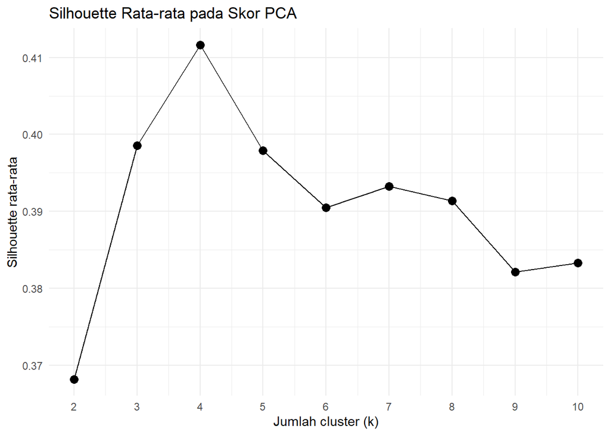

```r
ggplot(df_sil, aes(x = k, y = sil_avg)) +
  geom_point(size = 3) + geom_line() +
  scale_x_continuous(breaks = min_k:max_k) +
  labs(title = "Silhouette Rata-rata pada Skor PCA", x = "Jumlah cluster (k)", y = "Silhouette rata-rata") +
  theme_minimal()
```

```r
message("Silhouette tertinggi: k = ", df_sil$k[which.max(df_sil$sil_avg)],
        " dengan skor ", round(max(df_sil$sil_avg), 3))
```

```
## Silhouette tertinggi: k = 4 dengan skor 0.412
```

# KMeans dan plot

```r
k_pilih <- 4

set.seed(42)
km <- kmeans(data_pca, centers = k_pilih, nstart = 50)

data_pca_cluster <- cbind(data_pca, cluster = factor(km$cluster))
centers_pca <- as.data.frame(km$centers); centers_pca$cluster <- factor(1:nrow(centers_pca))

# Ukuran cluster
print(table(data_pca_cluster$cluster))
```

```
##
##   1   2   3   4
## 550 819 354 544
```

```r
print(centers_pca)
```

```
##          PC1        PC2 cluster
## 1 -1.2968257  0.8591749       1
## 2 -0.4258736 -0.9894873       2
## 3  2.0187337 -0.2471633       3
## 4  0.6386266  0.7818745       4
```

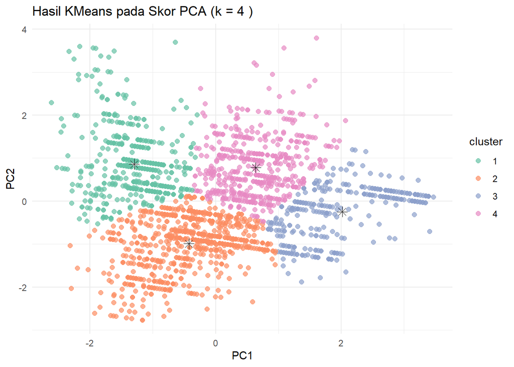

```r
# Plot (PC1 vs PC2) — hanya jika n_pc >= 2
if (ncol(data_pca) >= 2) {
  ggplot(data_pca_cluster, aes(x = PC1, y = PC2, color = cluster)) +
    geom_point(alpha = 0.7, size = 2) +
    geom_point(data = centers_pca, aes(x = PC1, y = PC2), color = "black", shape = 8, size = 3) +
    labs(title = paste("Hasil KMeans pada Skor PCA (k =", k_pilih, ")"), x = "PC1", y = "PC2") +
    theme_minimal() +
    scale_color_brewer(palette = "Set2")
} else {
  message("n_pc < 2: tidak dapat mem-plot PC1 vs PC2")
}
```

```r
df_cluster <- df
df_cluster$cluster <- factor(km$cluster)

ringkasan <- df_cluster %>%
  group_by(cluster) %>%
  summarise(across(everything(),
                   list(mean = ~ mean(.x, na.rm = TRUE),
                        sd = ~ sd(.x, na.rm = TRUE)),
                   .names = "{.col}_{.fn}"),
            jumlah = n())

print(ringkasan)
```

```
## # A tibble: 4 × 10
##   cluster Age_mean Age_sd Work_Experience_mean Work_Experience_sd
##   <fct>      <dbl>  <dbl>                <dbl>              <dbl>
## 1 1           27.1   6.61                 2.03               2.88
## 2 2           40.1  10.2                  4.33               3.99
## 3 3           71.4  10.7                  1.12               1.90
## 4 4           46.9   9.51                 1.31               1.90
## # ℹ 5 more variables: Family_Size_mean <dbl>, Family_Size_sd <dbl>,
## #   Spending_Score_mean <dbl>, Spending_Score_sd <dbl>, jumlah <int>
```

```r
print(table(df_cluster$cluster))
```

```
##
##   1   2   3   4
## 550 819 354 544
```

*Interpretasi* Berdasarkan hasil analisis K-Means clustering pada skor PCA, proses penentuan jumlah cluster diawali dengan evaluasi rata-rata silhouette. Dari grafik silhouette, terlihat bahwa nilai rata-rata tertinggi dicapai pada k = 4 (sekitar 0,41), yang berarti pemisahan data menjadi empat kelompok memberikan keseimbangan terbaik antara homogenitas dalam cluster dan perbedaan antar cluster. Nilai silhouette yang tidak terlalu tinggi namun stabil (>0,38) pada sebagian besar nilai k menunjukkan bahwa struktur kelompok memang ada, tetapi tidak sangat tajam — artinya data memiliki kecenderungan membentuk beberapa kelompok alami, meskipun dengan tumpang tindih yang moderat antar batas cluster.

Ketika model K-Means diterapkan dengan k = 4, hasil visualisasi pada ruang dua komponen utama (PC1 dan PC2) memperlihatkan pembentukan empat area yang cukup terpisah. Masing-masing cluster memiliki sebaran yang khas di ruang PCA:

Cluster 1 (hijau) terletak di sisi kiri atas, cenderung memiliki nilai PC1 rendah (usia dan spending score lebih rendah) tetapi PC2 tinggi (ukuran keluarga relatif besar, pengalaman kerja lebih sedikit).

Cluster 2 (oranye) berada di kiri bawah, mencerminkan individu dengan usia dan spending score rendah serta pengalaman kerja lebih tinggi, mengingat arah PC2 yang negatif.

Cluster 3 (biru) berada di sisi kanan bawah, mewakili individu dengan usia dan spending score tinggi namun ukuran keluarga kecil.

Titik bintang hitam di tengah setiap warna menunjukkan pusat cluster (centroid), yang merepresentasikan rata-rata posisi setiap kelompok dalam ruang dua dimensi hasil PCA. Posisi centroid yang terpisah menunjukkan bahwa K-Means berhasil memisahkan kelompok berdasarkan pola utama yang ditangkap oleh PCA, yaitu kombinasi antara dimensi “usia–pengeluaran” (PC1) dan “ukuran keluarga–pengalaman kerja” (PC2). Dengan demikian, dapat disimpulkan bahwa pemilihan empat cluster (k=4) merupakan solusi optimal untuk menggambarkan struktur alami data ini, di mana tiap cluster mencerminkan kombinasi unik antara usia, tingkat pengeluaran, ukuran keluarga, dan pengalaman kerja individu.